# Advanced R

# 3. Dataframes

A dataframe is a table, usually with column identifiers (column names) and sometimes with row identifiers (indexes). Let’s see the iris dataset:

```r
#iris
dim(iris) # number of rows x number of columns
```

```
## [1] 150   5
```

```r
length(iris) # the number of columns
```

```
## [1] 5
```

```r
nrow(iris) # the number of rows
```

```
## [1] 150
```

```r
ncol(iris) # the number of columns
```

```
## [1] 5
```

```r
colnames(iris) # self-explanatory
```

```
## [1] "Sepal.Length" "Sepal.Width"  "Petal.Length" "Petal.Width"  "Species"
```

```r
rownames(iris) # this dataset doesn't have specific row names so just a number
```

```
##   [1] "1"   "2"   "3"   "4"   "5"   "6"   "7"   "8"   "9"   "10"  "11"  "12"
##  [13] "13"  "14"  "15"  "16"  "17"  "18"  "19"  "20"  "21"  "22"  "23"  "24"
##  [25] "25"  "26"  "27"  "28"  "29"  "30"  "31"  "32"  "33"  "34"  "35"  "36"
##  [37] "37"  "38"  "39"  "40"  "41"  "42"  "43"  "44"  "45"  "46"  "47"  "48"
##  [49] "49"  "50"  "51"  "52"  "53"  "54"  "55"  "56"  "57"  "58"  "59"  "60"
##  [61] "61"  "62"  "63"  "64"  "65"  "66"  "67"  "68"  "69"  "70"  "71"  "72"
##  [73] "73"  "74"  "75"  "76"  "77"  "78"  "79"  "80"  "81"  "82"  "83"  "84"
##  [85] "85"  "86"  "87"  "88"  "89"  "90"  "91"  "92"  "93"  "94"  "95"  "96"
##  [97] "97"  "98"  "99"  "100" "101" "102" "103" "104" "105" "106" "107" "108"
## [109] "109" "110" "111" "112" "113" "114" "115" "116" "117" "118" "119" "120"
## [121] "121" "122" "123" "124" "125" "126" "127" "128" "129" "130" "131" "132"
## [133] "133" "134" "135" "136" "137" "138" "139" "140" "141" "142" "143" "144"
## [145] "145" "146" "147" "148" "149" "150"
```

```r
head(iris) # first few rows
```

```
##   Sepal.Length Sepal.Width Petal.Length Petal.Width Species
## 1          5.1         3.5          1.4         0.2  setosa
## 2          4.9         3.0          1.4         0.2  setosa
## 3          4.7         3.2          1.3         0.2  setosa
## 4          4.6         3.1          1.5         0.2  setosa
## 5          5.0         3.6          1.4         0.2  setosa
## 6          5.4         3.9          1.7         0.4  setosa
```

```r
tail(iris) # last few rows
```

```
##     Sepal.Length Sepal.Width Petal.Length Petal.Width   Species
## 145          6.7         3.3          5.7         2.5 virginica
## 146          6.7         3.0          5.2         2.3 virginica
## 147          6.3         2.5          5.0         1.9 virginica
## 148          6.5         3.0          5.2         2.0 virginica
## 149          6.2         3.4          5.4         2.3 virginica
## 150          5.9         3.0          5.1         1.8 virginica
```

```r
str(iris) # structure of dataframe, dims and classes
```

```
## 'data.frame':    150 obs. of  5 variables:
##  $ Sepal.Length: num  5.1 4.9 4.7 4.6 5 5.4 4.6 5 4.4 4.9 ...
##  $ Sepal.Width : num  3.5 3 3.2 3.1 3.6 3.9 3.4 3.4 2.9 3.1 ...
##  $ Petal.Length: num  1.4 1.4 1.3 1.5 1.4 1.7 1.4 1.5 1.4 1.5 ...
##  $ Petal.Width : num  0.2 0.2 0.2 0.2 0.2 0.4 0.3 0.2 0.2 0.1 ...
##  $ Species     : Factor w/ 3 levels "setosa","versicolor",..: 1 1 1 1 1 1 1 1 1 1 ...
```

```r
summary(iris) # summary statistics
```

```
##   Sepal.Length    Sepal.Width     Petal.Length    Petal.Width
##  Min.   :4.300   Min.   :2.000   Min.   :1.000   Min.   :0.100
##  1st Qu.:5.100   1st Qu.:2.800   1st Qu.:1.600   1st Qu.:0.300
##  Median :5.800   Median :3.000   Median :4.350   Median :1.300
##  Mean   :5.843   Mean   :3.057   Mean   :3.758   Mean   :1.199
##  3rd Qu.:6.400   3rd Qu.:3.300   3rd Qu.:5.100   3rd Qu.:1.800
##  Max.   :7.900   Max.   :4.400   Max.   :6.900   Max.   :2.500
##        Species
##  setosa    :50
##  versicolor:50
##  virginica :50
##
##
##
```

```r
View(iris) # opens a new window with the dataset
```

## Summary info of a dataframe

Base R has plenty of functions to get information from a dataset, like *summary*.

```r
summary(iris)
```

```
##   Sepal.Length    Sepal.Width     Petal.Length    Petal.Width
##  Min.   :4.300   Min.   :2.000   Min.   :1.000   Min.   :0.100
##  1st Qu.:5.100   1st Qu.:2.800   1st Qu.:1.600   1st Qu.:0.300
##  Median :5.800   Median :3.000   Median :4.350   Median :1.300
##  Mean   :5.843   Mean   :3.057   Mean   :3.758   Mean   :1.199
##  3rd Qu.:6.400   3rd Qu.:3.300   3rd Qu.:5.100   3rd Qu.:1.800
##  Max.   :7.900   Max.   :4.400   Max.   :6.900   Max.   :2.500
##        Species
##  setosa    :50
##  versicolor:50
##  virginica :50
##
##
##
```

Or use *skim* from the library *skimr*; *skim* returns a dataframe with a tidier description of each variable.

```r
skim(iris)
```

Data summary

| Name | iris |
| --- | --- |
| Number of rows | 150 |
| Number of columns | 5 |
| _______________________ |  |
| Column type frequency: |  |
| factor | 1 |
| numeric | 4 |
| ________________________ |  |
| Group variables | None |

**Variable type: factor**

| skim_variable | n_missing | complete_rate | ordered | n_unique | top_counts |
| --- | --- | --- | --- | --- | --- |
| Species | 0 | 1 | FALSE | 3 | set: 50, ver: 50, vir: 50 |

**Variable type: numeric**

| skim_variable | n_missing | complete_rate | mean | sd | p0 | p25 | p50 | p75 | p100 | hist |
| --- | --- | --- | --- | --- | --- | --- | --- | --- | --- | --- |
| Sepal.Length | 0 | 1 | 5.84 | 0.83 | 4.3 | 5.1 | 5.80 | 6.4 | 7.9 | ▆▇▇▅▂ |
| Sepal.Width | 0 | 1 | 3.06 | 0.44 | 2.0 | 2.8 | 3.00 | 3.3 | 4.4 | ▁▆▇▂▁ |
| Petal.Length | 0 | 1 | 3.76 | 1.77 | 1.0 | 1.6 | 4.35 | 5.1 | 6.9 | ▇▁▆▇▂ |
| Petal.Width | 0 | 1 | 1.20 | 0.76 | 0.1 | 0.3 | 1.30 | 1.8 | 2.5 | ▇▁▇▅▃ |

## Creating a dataframe from scratch

To create a dataframe (not very common; you probably won’t do this ever, just load a dataset using *readr*) one can use Base R *data.frame* or tidyverse’s *tibble*:

```r
my_df <- data.frame(
  "Date_ymd" = c("2025/3/26", "2025/3/27"),
  "Class" = c("Advanced R", "Data Manipulation with Python"),
  "Teacher" = "Carlos H." # Data frame creation recycles data when the vectors in each column are not the same length.
)
my_df
```

```
##    Date_ymd                         Class   Teacher
## 1 2025/3/26                    Advanced R Carlos H.
## 2 2025/3/27 Data Manipulation with Python Carlos H.
```

```r
class(my_df)
```

```
## [1] "data.frame"
```

## Creating new columns and rows

To create new columns, there is a straightforward way with ‘$’, ‘[]’ or with ‘[[]]’.

```r
my_df$new_col <- 1
my_df[["new_col2"]] <- 2
my_df["new_col3"] <- 3
my_df
```

```
##    Date_ymd                         Class   Teacher new_col new_col2 new_col3
## 1 2025/3/26                    Advanced R Carlos H.       1        2        3
## 2 2025/3/27 Data Manipulation with Python Carlos H.       1        2        3
```

Dataframes can also be concatenated with other dataframes using *cbind* or *rbind* (columns and rows).

### Mini-Exercise: Concatenation

```r
# create a row and a column and bind them to 'my_df' using cbind and rbind
```

## Changing the names of columns

To change the column names.

```r
colnames(my_df)[3] <- "Professor"
my_df
```

```
##    Date_ymd                         Class Professor new_col new_col2 new_col3
## 1 2025/3/26                    Advanced R Carlos H.       1        2        3
## 2 2025/3/27 Data Manipulation with Python Carlos H.       1        2        3
```

## Accesing data inside a dataframe: Slicing

To access columns (or rows) in the dataframe we can use ‘[]’, ‘[[]]’ or ‘$' ('$’ only for the columns) (the difference is the type of output, check with *class()*):

```r
my_df["Class"]
```

```
##                           Class
## 1                    Advanced R
## 2 Data Manipulation with Python
```

```r
#class(my_df["Class"]) # a dataframe
my_df$Class
```

```
## [1] "Advanced R"                    "Data Manipulation with Python"
```

```r
#class(my_df$Class) # a vector
my_df[["Class"]]
```

```
## [1] "Advanced R"                    "Data Manipulation with Python"
```

```r
#class(my_df[["Class"]]) # a vector
```

To further access information in a dataframe you will have to add the index (or indexes):

```r
iris[1:5, c("Species", "Sepal.Length")]
```

```
##   Species Sepal.Length
## 1  setosa          5.1
## 2  setosa          4.9
## 3  setosa          4.7
## 4  setosa          4.6
## 5  setosa          5.0
```

```r
iris[1:5, 1:2] # dataframe[row_slice, column_slice]
```

```
##   Sepal.Length Sepal.Width
## 1          5.1         3.5
## 2          4.9         3.0
## 3          4.7         3.2
## 4          4.6         3.1
## 5          5.0         3.6
```

```r
iris[1:5,] # if there is no value before or after the comma, it takes the whole range of values possible for that field (row/col)
```

```
##   Sepal.Length Sepal.Width Petal.Length Petal.Width Species
## 1          5.1         3.5          1.4         0.2  setosa
## 2          4.9         3.0          1.4         0.2  setosa
## 3          4.7         3.2          1.3         0.2  setosa
## 4          4.6         3.1          1.5         0.2  setosa
## 5          5.0         3.6          1.4         0.2  setosa
```

### Slicing by condition

There is also the possibility of slicing a dataset using conditions using ‘[]’. We will see more after “Loading a dataset”.

```r
iris[iris$Species == "setosa",]
```

```
##    Sepal.Length Sepal.Width Petal.Length Petal.Width Species
## 1           5.1         3.5          1.4         0.2  setosa
## 2           4.9         3.0          1.4         0.2  setosa
## 3           4.7         3.2          1.3         0.2  setosa
## 4           4.6         3.1          1.5         0.2  setosa
## 5           5.0         3.6          1.4         0.2  setosa
## 6           5.4         3.9          1.7         0.4  setosa
## 7           4.6         3.4          1.4         0.3  setosa
## 8           5.0         3.4          1.5         0.2  setosa
## 9           4.4         2.9          1.4         0.2  setosa
## 10          4.9         3.1          1.5         0.1  setosa
## 11          5.4         3.7          1.5         0.2  setosa
## 12          4.8         3.4          1.6         0.2  setosa
## 13          4.8         3.0          1.4         0.1  setosa
## 14          4.3         3.0          1.1         0.1  setosa
```

[output cut: 36 more lines]

## Loading a dataset

As I commented before, most of the time you will not create a dataframe manually. You will download a dataset (an csv, excel, etc) and load it into your code.

There is a folder called *datasets* in the github repo. My best advice is that if possible don’t bother writing the code for the loading:

1. Go to the Files Tab on the bottom-right part of RStudio.
2. Go to the folder (datasets) where the dataset is stored.
3. Left-click it and click “Import Dataset…”.
4. A new window will pop up. There are several options, like to trim the whitespaces from character fields, avoid NAs, skip rows, select the type of column ,etc.
5. Once you have tinkered with the options to load your data. Copy the code from the “Code Preview” field and paste it into the code.

```r
library(readr)
olive_original <- read_csv("datasets/olive_original.csv")
olive_original
```

```
## # A tibble: 572 × 10
##    region  area  palmitic palmitoleic stearic oleic linoleic linolenic arachidic
##    <chr>   <chr>    <dbl>       <dbl>   <dbl> <dbl>    <dbl>     <dbl>     <dbl>
##  1 Southe… Nort…    10.8         0.75    2.26  78.2     6.72      0.36      0.6
##  2 Southe… Nort…    10.9         0.73    2.24  77.1     7.81      0.31      0.61
##  3 Southe… Nort…     9.11        0.54    2.46  81.1     5.49      0.31      0.63
##  4 Southe… Nort…     9.66        0.57    2.4   79.5     6.19      0.5       0.78
##  5 Southe… Nort…    10.5         0.67    2.59  77.7     6.72      0.5       0.8
##  6 Southe… Nort…     9.11        0.49    2.68  79.2     6.78      0.51      0.7
##  7 Southe… Nort…     9.22        0.66    2.64  79.9     6.18      0.49      0.56
##  8 Southe… Nort…    11           0.61    2.35  77.3     7.34      0.39      0.64
##  9 Southe… Nort…    10.8         0.6     2.39  77.4     7.09      0.46      0.83
## 10 Southe… Nort…    10.4         0.55    2.13  79.4     6.33      0.26      0.52
## # ℹ 562 more rows
## # ℹ 1 more variable: eicosenoic <dbl>
```

Once the dataset is loaded into a dataframe is recommended to use *summary* or *skim* to see the statistical information.

```r
skim(olive_original)
```

Data summary

| Name | olive_original |
| --- | --- |
| Number of rows | 572 |
| Number of columns | 10 |
| _______________________ |  |
| Column type frequency: |  |
| character | 2 |
| numeric | 8 |
| ________________________ |  |
| Group variables | None |

**Variable type: character**

| skim_variable | n_missing | complete_rate | min | max | empty | n_unique | whitespace |
| --- | --- | --- | --- | --- | --- | --- | --- |
| region | 0 | 1 | 8 | 14 | 0 | 3 | 0 |
| area | 0 | 1 | 6 | 15 | 0 | 9 | 0 |

**Variable type: numeric**

| skim_variable | n_missing | complete_rate | mean | sd | p0 | p25 | p50 | p75 | p100 | hist |
| --- | --- | --- | --- | --- | --- | --- | --- | --- | --- | --- |
| palmitic | 0 | 1 | 12.32 | 1.69 | 6.10 | 10.95 | 12.01 | 13.60 | 17.53 | ▁▂▇▆▁ |
| palmitoleic | 0 | 1 | 1.26 | 0.52 | 0.15 | 0.88 | 1.10 | 1.69 | 2.80 | ▂▇▅▃▁ |
| stearic | 0 | 1 | 2.29 | 0.37 | 1.52 | 2.05 | 2.23 | 2.49 | 3.75 | ▂▇▃▁▁ |
| oleic | 0 | 1 | 73.12 | 4.06 | 63.00 | 70.00 | 73.03 | 76.80 | 84.10 | ▁▇▇▇▁ |
| linoleic | 0 | 1 | 9.81 | 2.43 | 4.48 | 7.71 | 10.30 | 11.81 | 14.70 | ▃▅▃▇▃ |
| linolenic | 0 | 1 | 0.32 | 0.13 | 0.00 | 0.26 | 0.33 | 0.40 | 0.74 | ▂▅▇▂▁ |
| arachidic | 0 | 1 | 0.58 | 0.22 | 0.00 | 0.50 | 0.61 | 0.70 | 1.05 | ▂▁▇▇▂ |
| eicosenoic | 0 | 1 | 0.16 | 0.14 | 0.01 | 0.02 | 0.17 | 0.28 | 0.58 | ▇▃▅▂▁ |

## Accesing data inside a dataframe: Conditional slicing with subset()

```r
median(olive_original$oleic)
```

```
## [1] 73.025
```

```r
olive_original %>% subset(region == "Southern Italy" & oleic < median(oleic))
```

```
## # A tibble: 246 × 10
##    region  area  palmitic palmitoleic stearic oleic linoleic linolenic arachidic
##    <chr>   <chr>    <dbl>       <dbl>   <dbl> <dbl>    <dbl>     <dbl>     <dbl>
##  1 Southe… Cala…     13.2        1.39    2.3   73.0     8.32      0.42      0.6
##  2 Southe… Cala…     13.2        1.36    2.17  71.7     9.5       0.43      0.63
##  3 Southe… Cala…     13.6        1.15    2.46  72.3     8.74      0.45      0.63
##  4 Southe… Cala…     13.8        1.11    2.72  71.3     9.4       0.46      0.64
##  5 Southe… Cala…     13.0        1.09    2.45  72.5     9.03      0.43      0.62
##  6 Southe… Cala…     12.8        1.21    2.15  72.8     8.92      0.4       0.68
##  7 Southe… Cala…     13.4        1.2     3.18  70.8     9.15      0.5       0.7
##  8 Southe… Cala…     13.1        1.22    2.41  72.6     8.7       0.46      0.72
##  9 Southe… Cala…     12.5        1.07    3.13  73.0     8.4       0.46      0.66
## 10 Southe… Cala…     13.6        1.06    2.36  72.1     8.66      0.48      0.75
## # ℹ 236 more rows
## # ℹ 1 more variable: eicosenoic <dbl>
```

```r
olive_original %>% subset(region == "Southern Italy") %>% subset(oleic < median(oleic))
```

```
## # A tibble: 161 × 10
##    region  area  palmitic palmitoleic stearic oleic linoleic linolenic arachidic
##    <chr>   <chr>    <dbl>       <dbl>   <dbl> <dbl>    <dbl>     <dbl>     <dbl>
##  1 Southe… Cala…     14.3        1.52    2.81  70.3     9.49      0.39      0.55
##  2 Southe… Sout…     13.6        2.04    2.25  69.3    10.8       0.21      0.5
##  3 Southe… Sout…     14.1        1.85    2.17  68.4    12.0       0.34      0.72
##  4 Southe… Sout…     14.1        2.32    2.8   67.2    12.3       0.32      0.6
##  5 Southe… Sout…     15.1        2.09    2.57  66.5    12.4       0.42      0.62
##  6 Southe… Sout…     12.7        1.91    2.02  68.6    13.0       0.43      0.7
##  7 Southe… Sout…     14.6        1.83    1.83  67.5    13.1       0.36      0.6
##  8 Southe… Sout…     14.0        1.87    1.91  68.6    12.3       0.38      0.6
##  9 Southe… Sout…     14.1        1.93    2.08  68.8    12.0       0.3       0.6
## 10 Southe… Sout…     13.7        2.06    2.03  69.5    11.7       0.35      0.5
## # ℹ 151 more rows
## # ℹ 1 more variable: eicosenoic <dbl>
```

To select one or more columns (or exclude) we can use the ‘select’ option inside *subset* or use dplyr’s *select* function:

```r
olive_original %>% subset(region == "Southern Italy") %>% subset(oleic < median(oleic), select=-region) # base R with dplyr pipe;
```

```
## # A tibble: 161 × 9
##    area         palmitic palmitoleic stearic oleic linoleic linolenic arachidic
##    <chr>           <dbl>       <dbl>   <dbl> <dbl>    <dbl>     <dbl>     <dbl>
##  1 Calabria         14.3        1.52    2.81  70.3     9.49      0.39      0.55
##  2 South-Apulia     13.6        2.04    2.25  69.3    10.8       0.21      0.5
##  3 South-Apulia     14.1        1.85    2.17  68.4    12.0       0.34      0.72
##  4 South-Apulia     14.1        2.32    2.8   67.2    12.3       0.32      0.6
##  5 South-Apulia     15.1        2.09    2.57  66.5    12.4       0.42      0.62
##  6 South-Apulia     12.7        1.91    2.02  68.6    13.0       0.43      0.7
##  7 South-Apulia     14.6        1.83    1.83  67.5    13.1       0.36      0.6
##  8 South-Apulia     14.0        1.87    1.91  68.6    12.3       0.38      0.6
##  9 South-Apulia     14.1        1.93    2.08  68.8    12.0       0.3       0.6
## 10 South-Apulia     13.7        2.06    2.03  69.5    11.7       0.35      0.5
## # ℹ 151 more rows
## # ℹ 1 more variable: eicosenoic <dbl>
```

```r
olive_original %>% subset(region == "Southern Italy") %>% subset(oleic < median(oleic)) %>% select(-region) #dplyr
```

```
## # A tibble: 161 × 9
##    area         palmitic palmitoleic stearic oleic linoleic linolenic arachidic
##    <chr>           <dbl>       <dbl>   <dbl> <dbl>    <dbl>     <dbl>     <dbl>
##  1 Calabria         14.3        1.52    2.81  70.3     9.49      0.39      0.55
##  2 South-Apulia     13.6        2.04    2.25  69.3    10.8       0.21      0.5
##  3 South-Apulia     14.1        1.85    2.17  68.4    12.0       0.34      0.72
##  4 South-Apulia     14.1        2.32    2.8   67.2    12.3       0.32      0.6
##  5 South-Apulia     15.1        2.09    2.57  66.5    12.4       0.42      0.62
##  6 South-Apulia     12.7        1.91    2.02  68.6    13.0       0.43      0.7
##  7 South-Apulia     14.6        1.83    1.83  67.5    13.1       0.36      0.6
##  8 South-Apulia     14.0        1.87    1.91  68.6    12.3       0.38      0.6
##  9 South-Apulia     14.1        1.93    2.08  68.8    12.0       0.3       0.6
## 10 South-Apulia     13.7        2.06    2.03  69.5    11.7       0.35      0.5
## # ℹ 151 more rows
## # ℹ 1 more variable: eicosenoic <dbl>
```

Writing code using *subset* is cleaner and easier to do. So focus on learning well how to use it.

## Saving a dataframe into a file.

In our case we will save it to a .csv file but there are more types (tsv, excel, etc)

```r
data("olive")
write_csv(olive, "./datasets/olive_original.csv")
```

## Dataframe Exercise

# 4. Plotting Base R

R has very good plotting in its Base programming, but, as you will see in the next class, ggplot is better.

Plotting has a lot of different options so I won’t be able to teach all of them in just one class but you can visit https://r-graph-gallery.com/base-R.html to see Base R plotting examples.

That web is also good to learn what is possible with ggplot.

Useful parameters:

- Titles
- Legends
- Annotations
- Adding straight lines (e.g. mean)
- Scaling the axis
- Customize tick marks
- Plotting symbols
- Line Types
- Colors

### plot() example and Exercise

As you can see there are a lot of parameters/options and kinds of plots. The tasks are the following:

Using the mtcars dataset.

```r
head(mtcars)
```

```
##                    mpg cyl disp  hp drat    wt  qsec vs am gear carb
## Mazda RX4         21.0   6  160 110 3.90 2.620 16.46  0  1    4    4
## Mazda RX4 Wag     21.0   6  160 110 3.90 2.875 17.02  0  1    4    4
## Datsun 710        22.8   4  108  93 3.85 2.320 18.61  1  1    4    1
## Hornet 4 Drive    21.4   6  258 110 3.08 3.215 19.44  1  0    3    1
## Hornet Sportabout 18.7   8  360 175 3.15 3.440 17.02  0  0    3    2
## Valiant           18.1   6  225 105 2.76 3.460 20.22  1  0    3    1
```

- Scatter Plot of Miles per Gallon vs. Horsepower Create a scatter plot showing the relationship between Miles per Gallon (mpg) and Horsepower (hp). Customize the plot with a title and axis labels. Use blue color and solid circles for the points.
- Boxplot of Miles per Gallon by Number of Cylinders Create a boxplot comparing Miles per Gallon (mpg) for cars with different numbers of cylinders (cyl). Add a title and axis labels. Color the boxes light green.
- Histogram of Miles per Gallon Create a histogram that shows the distribution of Miles per Gallon (mpg) across the cars in the dataset. Customize the plot with a title, axis labels, orange-colored bars, and black borders. Set the number of bins to 10.
- Bar Plot of Frequency of Different Numbers of Cylinders Create a bar plot that shows the frequency of cars with different numbers of cylinders (cyl). Add appropriate axis labels and color the bars purple.
- Correlation Heatmap of All Numeric Variables Create a heatmap that visualizes the correlation matrix of all numeric variables in the mtcars dataset. Use an appropriate color scale (e.g., heat.colors()) and ensure the heatmap is clearly labeled.

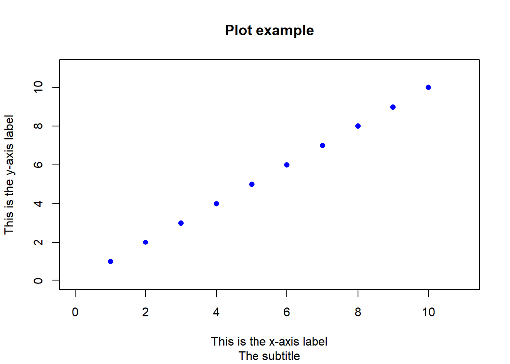

```r
plot(x = 1:10,                         # x-coordinates
     y = 1:10,                         # y-coordinates
     type = "p",                       # Just draw points (no lines)
     main = "Plot example",
     sub = "The subtitle",
     xlab = "This is the x-axis label",
     ylab = "This is the y-axis label",
     xlim = c(0, 11),                  # Min and max values for x-axis
     ylim = c(0, 11),                  # Min and max values for y-axis
     col = "blue",                     # Color of the points
     pch = 16,                         # Type of symbol (16 means Filled circle)
     cex = 1)                           # Size of the symbols
```

```r
# Scatter plot: mpg vs hp
```

```r
# Boxplot: mpg by cyl (number of cylinders)
```

```r
# Histogram of mpg (Miles per Gallon)
```

```r
# Bar plot: Frequency of different numbers of cylinders
```

```r
# Correlation plot of numeric variables;
```